# Measuring, Modeling, and Forecasting Volatility

Every notebook so far has treated the volatility of returns as a single fixed number to be estimated -- the sample standard deviation in `Security_Returns_Properties.ipynb`, or the $\sigma$ behind the standard error of the mean in `Equity_Premium_Inference.ipynb`. This notebook asks whether volatility itself moves around over time, and if so, how to measure it, model it, and forecast it. The short answer is that it moves a lot, and in a way that is surprisingly predictable.

The tools build directly on `TimeSeries.ipynb`. The two main approaches -- **GARCH models**, which treat volatility as a hidden (latent) variable inferred from returns, and **realized volatility**, which measures it directly from intraday data -- are both, at heart, autoregressive models of the kind developed there, applied to the *size* of returns rather than to returns themselves. The out-of-sample forecast comparison at the end follows the same approach as `PredictiveRegressions.ipynb`. The monthly market return data are the same Goyal-Welch series used in `Equity_Premium_Inference.ipynb`.

*Acknowledgment*: This notebook was produced with the assistance of AI. I remain responsible for the content and any errors.

## Learning Objectives

By the end of this notebook, you should be able to:

1. Define volatility, annualize it, and distinguish the *unconditional* variance of returns from the *conditional* variance.
2. Explain volatility clustering, and document it by comparing the autocorrelations of returns with those of absolute returns.
3. Explain what implied volatility (such as the VIX) measures, and why it differs from a pure forecast of future volatility.
4. Write down the ARCH(1) and GARCH(1,1) models, interpret their parameters, and derive the persistence and long-run (unconditional) variance they imply.
5. Estimate a GARCH(1,1) model by maximum likelihood with the `arch` package, interpret the output, and check whether the standardized residuals still show volatility clustering.
6. Derive multi-step GARCH variance forecasts, compute them in Python, and explain how they revert to the long-run variance.
7. Define realized variance, and use simulation to explain why sampling returns more frequently produces a more accurate measure of volatility.
8. Model and forecast realized volatility with AR and HAR regressions, and compare forecasts out of sample.
9. (Optional, appendix) Write down the GARCH log-likelihood and estimate the model "by hand" with a numerical optimizer.

## Instructions to Run

**Data:** This notebook uses three files, all read from the `data/` folder:

- `data/spy_etf_daily.csv` -- daily SPY closing prices, August 2020 onward (used in the motivating example). Already in this repo.
- `data/market_excess_monthly.csv` -- monthly U.S. stock market excess returns, January 1926 through December 2024, from Amit Goyal's update of the Goyal and Welch (2008) data. Already in this repo; it is the same file used in `Equity_Premium_Inference.ipynb`.
- `data/emini_sp500_5min.csv` -- 5-minute prices and log returns for S&P 500 E-mini futures, March 2015 through August 2017 (used in the realized volatility sections). This file is *not* in the repo. Like other data that is too large to track here or can't be redistributed (e.g. licensed WRDS data), it is posted on the course Canvas site under Data instead. Download it into your local `data/` folder before running.

**If your data lives somewhere else:** Edit the `pd.read_csv(...)` calls -- the first code cell (`spy_etf_daily.csv`), the first cell of "Volatility Clustering in Monthly Stock Returns" (`market_excess_monthly.csv`), and the first cell of the "Realized volatility of S&P 500 futures" subsection (`emini_sp500_5min.csv`). The paths assume this notebook lives in `notebooks/` and `data/` is a sibling folder.

**Package dependencies:** `numpy`, `pandas`, `matplotlib`, `statsmodels`, and `scipy` are standard Anaconda packages. The GARCH models use the `arch` package, which is *not* included in a typical Anaconda install: run `pip install arch` once before running this notebook (or `pip install numpy pandas matplotlib statsmodels scipy arch` if you are not using Anaconda).

**Viewing the HTML export in Canvas:** If the equations below show up as raw text (things like `$\sigma_t$`) instead of typeset math, don't use Canvas's built-in file preview -- download the file and open it directly in your browser instead. Canvas's preview sandboxes uploaded HTML and blocks the script that typesets the math; opening the downloaded file locally has no such restriction.

## Motivating Example: Two Weeks in April 2025

On the afternoon of April 2, 2025, the U.S. government announced a sweeping set of new tariffs on imports from nearly every country. Over the next two trading days, SPY (an ETF that tracks the S&P 500) fell about 5% and then about 6%. Then, on April 9, after a 90-day pause on most of the tariffs was announced, SPY *rose* about 10% in a single day -- one of the largest daily gains in its history -- before falling again by more than 4% the next day.

The code below loads daily SPY closing prices, computes daily log returns (in percent), and prints the returns for these two weeks. It also counts how often SPY moved by more than 2% in a day during 2024, a fairly calm year, for comparison.

```python
import numpy as np
import pandas as pd
import matplotlib.pyplot as plt
import statsmodels.api as sm
from statsmodels.tsa.ar_model import AutoReg, ar_select_order
from statsmodels.stats.diagnostic import acorr_ljungbox
from arch import arch_model

#Daily SPY closing prices (see Instructions to Run). Prices are not adjusted for dividends,
#which shifts the return on the few ex-dividend days by a fraction of a percent -- harmless here
spy = pd.read_csv("../data/spy_etf_daily.csv", parse_dates=["date"]).set_index("date")
spy['ret'] = 100 * np.log(spy['close_usd']).diff()   #daily log return, in percent
spy = spy.dropna()

print("SPY daily returns (%), April 1-11, 2025:")
print(spy.loc['2025-04-01':'2025-04-11', 'ret'].round(2).to_string())

big = spy['ret'].abs() > 2
print(f"\nDays with a move larger than 2% in 2024: {big.loc['2024'].sum()} of {big.loc['2024'].size}")
print(f"Days with a move larger than 2% in April 2025: {big.loc['2025-04'].sum()} of {big.loc['2025-04'].size}")
```

```
SPY daily returns (%), April 1-11, 2025:
date
2025-04-01    0.28
2025-04-02    0.63
2025-04-03   -5.05
2025-04-04   -6.03
2025-04-07   -0.18
2025-04-08   -1.58
2025-04-09    9.99
2025-04-10   -4.48
2025-04-11    1.77

Days with a move larger than 2% in 2024: 7 of 252
Days with a move larger than 2% in April 2025: 8 of 21
```

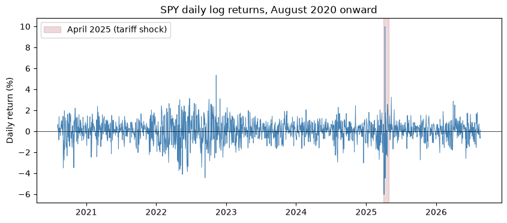

```python
fig, ax = plt.subplots(figsize=(10, 4))
ax.plot(spy.index, spy['ret'], color='steelblue', linewidth=0.7)
ax.axvspan(pd.Timestamp('2025-04-01'), pd.Timestamp('2025-04-30'), color='darkred', alpha=0.15,
           label='April 2025 (tariff shock)')
ax.axhline(0, color='black', linewidth=0.5)
ax.set_title("SPY daily log returns, August 2020 onward")
ax.set_ylabel("Daily return (%)")
ax.legend(loc='upper left')
plt.show()
```

Two things stand out. First, the *direction* of the big moves was not predictable: a 6% drop was followed, three trading days later, by a 10% gain. Nobody could have profited reliably by betting on the sign of the next day's return. Second, the *size* of the moves was very predictable in a loose sense: once the market started making big moves, it kept making big moves for weeks, and then gradually calmed down. The plot shows the same pattern elsewhere too: the 2022 bear market was a noticeably choppier stretch than most of 2021 or 2024.

This pattern -- unpredictable signs, but predictable magnitudes -- is called **volatility clustering**, and it is one of the most robust facts about financial returns. (The appendix of `TimeSeries.ipynb` used it as the leading example of a series that is uncorrelated but *not* independent.) It matters for anyone whose decisions depend on risk: a risk manager who used 2024's typical daily move to size a position in early April 2025 would have badly understated the risk. The rest of this notebook develops tools to measure this time-varying risk and to forecast it.

## Volatility and Conditional Volatility

### Volatility, and annualizing it

The **volatility** of an asset return $r_t$ is simply its standard deviation, $\sigma$. The **variance** is its square, $\sigma^2$. We usually report volatility rather than variance because volatility is in the same units as returns (percent per period), while variance is in "percent squared," which is hard to interpret.

Given a sample of $T$ returns with sample mean $\hat\mu$, the sample volatility is

$$\hat{\sigma} = \sqrt{\frac{1}{T-1}\sum_{t=1}^{T} (r_{t} - \hat{\mu})^2}.$$

(See `SampleVarianceSimulation.ipynb` for why we divide by $T-1$ rather than $T$; with the sample sizes in this notebook the difference is negligible.)

Volatility is usually **annualized** so that numbers computed from daily, weekly, or monthly data can be compared. If there are $M$ periods per year (e.g. $M = 12$ for monthly data, $M \approx 252$ for daily data), the annualized volatility is $\sqrt{M}\,\sigma$. The reason: the annual (log) return is the sum of the $M$ periodic returns, and if those are uncorrelated with a common variance $\sigma^2$, the variance of the sum is the sum of the variances,

$$\text{Var}(r_1 + r_2 + \cdots + r_M) = \sigma^2 + \sigma^2 + \cdots + \sigma^2 = M\sigma^2,$$

since all the covariance terms are zero. Taking the square root gives an annual volatility of $\sqrt{M}\,\sigma$. For example, U.S. stock market excess returns have a monthly volatility of a bit over 5%, which annualizes to $\sqrt{12} \times 5.4\% \approx 18.7\%$ per year.

### Unconditional versus conditional variance

So far we have talked about *the* variance of returns, $\sigma^2$, as if it were a single number. If volatility clusters, we need to be more careful, and distinguish two different variances.

The **unconditional variance** is the variance of returns averaged over a very long period: $\sigma^2 = E[(r_t - \mu)^2]$. It is the right answer to the question "how risky are stocks, in general?"

The **conditional variance** is the variance of this period's return *given everything known at the end of last period*, which we collect in an "information set" $I_{t-1}$ (past returns, past news, whether the economy is in a recession, and so on). Assuming for simplicity that the expected return is a constant $\mu$,

$$\sigma^2_t = E\big[(r_t - \mu)^2 \,\big|\, I_{t-1}\big].$$

In plain words: $\sigma^2_t$ is our best prediction, made at the end of period $t-1$, of how large the squared deviation of the coming period's return from its mean will be. The subscript $t$ on $\sigma^2_t$ signals that this prediction can change from period to period as new information arrives. The **conditional volatility** is its square root, $\sigma_t = \sqrt{\sigma^2_t}$.

*Example*: Suppose the market is more uncertain in recessions than in expansions. If $I_{t-1}$ includes an indicator of whether we are currently in a recession, then $\sigma^2_t$ is higher during recessions than during expansions. The unconditional variance is a weighted average of the two. If instead nothing in $I_{t-1}$ helps predict the size of the next return, then $\sigma^2_t = \sigma^2$ for every $t$: the conditional and unconditional variances coincide, and there is no volatility clustering.

### Why do we care?

Time-varying volatility means the risk of holding an asset changes over time. This matters for at least two reasons:

1. **Risk management.** Banks, funds, and other institutions monitor the risk of their positions daily, and are often subject to regulatory limits on that risk. A common risk measure, Value-at-Risk, is (roughly) a multiple of the position's conditional volatility -- so if conditional volatility doubles, the measured risk of an unchanged position doubles too. Using a long-run average volatility, as in the April 2025 example, would understate risk exactly when it matters most.
2. **Risk and return.** If investors demand compensation for bearing risk, then when conditional volatility rises, the expected return investors require may rise too. This is one possible explanation for the time variation in expected returns discussed in `PredictiveRegressions.ipynb`.

### Implied volatility (very briefly)

There is a second, quite different way to gauge current volatility conditions: from the prices of *options* on an asset. The Black-Scholes option pricing formula expresses the price of an option as a function of the price of the underlying asset, the strike price, the risk-free rate, the time to maturity, and the volatility of the underlying. All of these inputs except volatility are observable, so we can turn the formula around and ask: what volatility makes the formula match the option's observed market price? The answer is called the **implied volatility**.

The best-known example is the **VIX** index, which measures the implied volatility of the S&P 500 over the next 30 days from S&P 500 index option prices. The VIX moves around a lot, and tends to spike in "bad times" -- it jumped above 50 during the April 2025 tariff shock, compared with typical readings in the mid-teens during 2024. This is strong evidence that conditional volatility varies over time, and that it is countercyclical.

We will not use implied volatility in what follows, for one important reason: implied volatility is not a pure forecast of future volatility. Option prices reflect investors' attitudes toward risk as well as their expectations, and investors pay a premium for options that protect them against volatility spikes. As a result, implied volatility is typically *higher* than the volatility that subsequently materializes. The gap is called the **variance risk premium**, and it is a research topic of its own. In this notebook we instead model and forecast volatility directly from returns.

## Volatility Clustering in Monthly Stock Returns

The April 2025 episode covered only a few weeks. Is volatility clustering a general feature of stock returns, over long periods? To find out, we turn to nearly a century of monthly U.S. stock market excess returns (the same data as `Equity_Premium_Inference.ipynb`), converted to percent.

A simple way to see volatility over time is to plot the **absolute** return, $|r_t|$, each month. Volatility is about the *size* of returns, not their sign, so absolute returns strip out the sign and keep only the size. If volatility were constant, the absolute returns would scatter randomly around a flat level, with no long stretches of unusually large or unusually small values.

```
Sample: 1926-01 to 2024-12, T = 1188 months
Monthly volatility: 5.40%   Annualized: 18.7%
```

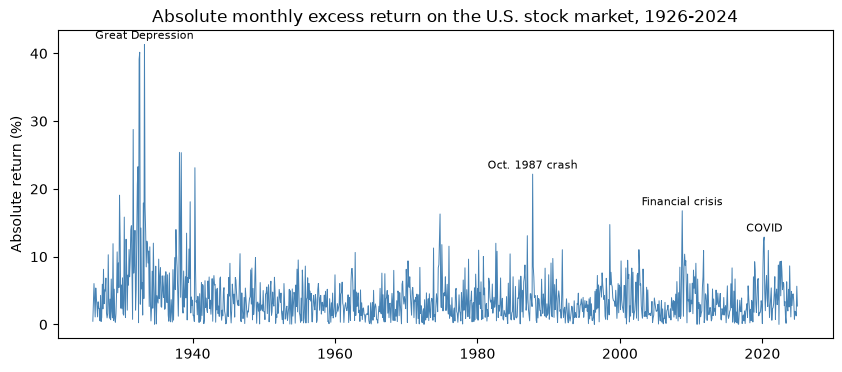

```python
#Monthly U.S. stock market excess returns, 1926-2024 (see Instructions to Run), converted to percent
mkt = pd.read_csv("../data/market_excess_monthly.csv", parse_dates=["date"]).set_index("date")
r = 100 * mkt['sp500_exret']
r.name = 'exret'
print(f"Sample: {r.index[0]:%Y-%m} to {r.index[-1]:%Y-%m}, T = {len(r)} months")
print(f"Monthly volatility: {r.std():.2f}%   Annualized: {np.sqrt(12) * r.std():.1f}%")

fig, ax = plt.subplots(figsize=(10, 4))
ax.plot(r.index, r.abs(), color='steelblue', linewidth=0.7)
for (start, end), note in [(('1931', '1933'), 'Great Depression'), (('1987-10', '1987-10'), 'Oct. 1987 crash'),
                           (('2008', '2009'), 'Financial crisis'), (('2020', '2020'), 'COVID')]:
    peak = r.abs().loc[start:end].idxmax()           #label each episode at its largest absolute return
    ax.annotate(note, (peak, r.abs().loc[peak]), textcoords='offset points',
                xytext=(0, 4), ha='center', fontsize=8)
ax.set_title("Absolute monthly excess return on the U.S. stock market, 1926-2024")
ax.set_ylabel("Absolute return (%)")
plt.show()
```

Instead of random scatter around a flat level, we see two features:

1. **Long, wave-like swings** in the typical size of returns. Absolute returns are large for years at a time during the Great Depression and again (less dramatically) in the 1970s, around 2000-2002, and in 2008-2009, and they are small for long stretches such as the mid-1950s through mid-1960s, the early 1990s, and the mid-2010s. Since the high-volatility periods line up with recessions and crises, volatility appears to be *countercyclical*: higher in bad times.
2. **Occasional short-lived spikes**, such as the October 1987 crash, which do not seem to be followed by a long period of high volatility.

### Autocorrelations of returns versus absolute returns

The tools from `TimeSeries.ipynb` let us make this more precise. If volatility clusters, a large absolute return this month should predict a large absolute return next month, so absolute returns should be positively autocorrelated -- even though returns themselves are (nearly) uncorrelated. The code below plots the sample ACF of returns and of absolute returns side by side, with the usual 95% bands.

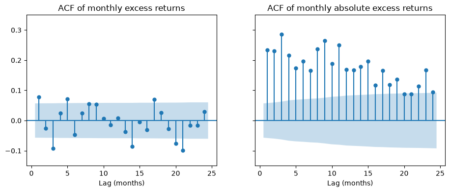

```python
fig, axes = plt.subplots(1, 2, figsize=(11, 4), sharey=True)
sm.graphics.tsa.plot_acf(r, lags=24, zero=False, ax=axes[0],
                         title="ACF of monthly excess returns")
sm.graphics.tsa.plot_acf(r.abs(), lags=24, zero=False, ax=axes[1],
                         title="ACF of monthly absolute excess returns")
for ax in axes:
    ax.set_xlabel("Lag (months)")
axes[0].set_ylim(-0.15, 0.35)
plt.show()
```

The contrast is stark. The autocorrelations of returns are small, and mostly inside the bands: as we saw in earlier notebooks, past returns tell us little about the direction of future returns. The autocorrelations of *absolute* returns are around 0.2 to 0.3 for the first year of lags, far outside the bands, and they die out extremely slowly: they are all positive, and still around 0.1 to 0.15 two years out, near the edge of the bands. The size of returns is persistent, even though the sign is not.

That is volatility clustering, in nearly a century of data. The next question is how to model it.

## ARCH and GARCH Models

One approach to modeling time-varying volatility is to write down an explicit equation for how the conditional variance $\sigma^2_t$ evolves over time. This is the approach of the **GARCH** family of models -- **G**eneralized **A**uto**R**egressive **C**onditional **H**eteroskedasticity. (That's a mouthful! "Heteroskedasticity" just means non-constant variance, and "conditional" means it is the conditional variance that changes.) The ideas earned Robert Engle a share of the 2003 Nobel Prize in Economics.

In a nutshell, GARCH models are autoregressive models, like the AR models in `TimeSeries.ipynb`, but for the *variance* of a series rather than for the series itself.

### The ARCH(1) model

The simplest version is the ARCH(1) model:

$$\begin{aligned} r_{t} &= \mu + \epsilon_{t}, \\ \epsilon_{t} &= \sigma_{t}\, e_{t}, \qquad e_t \sim \text{iid } N(0,1), \\ \sigma^2_{t} &= \omega + \alpha\, \epsilon^2_{t-1}. \end{aligned}$$

Reading it line by line:

- The first line says the return is a constant mean $\mu$ plus a "shock" (news) $\epsilon_t$.
- The second line says the shock is a standard normal draw $e_t$, scaled up or down by the conditional volatility $\sigma_t$. Since $e_t$ has mean zero and variance one and is independent of the past, $\epsilon_t$ has conditional mean zero and conditional variance $\sigma^2_t$.
- The third line is the key one. It says the conditional variance this period depends on the *square* of last period's shock. A big surprise last period, of either sign, raises the variance this period; a quiet period lowers it. That is exactly volatility clustering. We need $\omega > 0$ and $\alpha \ge 0$ so that the variance is always positive.

### ARCH(1) as an AR(1) for squared shocks

A few lines of algebra show why "autoregressive" is in the name. Square the second equation, $\epsilon^2_t = \sigma^2_t e^2_t$, then add and subtract $\sigma^2_t$:

$$\epsilon^2_t = \sigma^2_t + \sigma^2_t(e^2_t - 1).$$

Now substitute the ARCH equation for the first $\sigma^2_t$:

$$\epsilon^2_t = \omega + \alpha\,\epsilon^2_{t-1} + \nu_t, \qquad \text{where } \nu_t \equiv \sigma^2_t(e^2_t - 1).$$

The term $\nu_t$ is the *volatility surprise*: how much larger or smaller this period's squared shock turned out to be than its predicted value $\sigma^2_t$. Its conditional mean is zero, because $\sigma^2_t$ is known at the end of $t-1$ and $E[e^2_t] = \text{Var}(e_t) = 1$:

$$E[\nu_t \mid I_{t-1}] = \sigma^2_t\,\big(E[e^2_t] - 1\big) = \sigma^2_t\,(1 - 1) = 0.$$

So the squared shocks follow an AR(1) with slope $\alpha$ and an unpredictable error. Everything we learned about the AR(1) in `TimeSeries.ipynb` now carries over to $\epsilon^2_t$. In particular, when $\alpha < 1$, the long-run mean of an AR(1) is (intercept)/(1 $-$ slope), so the **unconditional variance** is

$$\sigma^2 = E[\epsilon^2_t] = \frac{\omega}{1 - \alpha},$$

and the autocorrelations of the squared shocks decay geometrically, $\text{Corr}(\epsilon^2_t, \epsilon^2_{t-s}) = \alpha^s$. (This last result needs one extra technical condition, discussed in the appendix.)

The ARCH(1) model can be extended to include more lags of squared shocks, giving the ARCH($p$) model $\sigma^2_t = \omega + \alpha_1\epsilon^2_{t-1} + \cdots + \alpha_p\epsilon^2_{t-p}$ -- the volatility counterpart of the AR($p$).

### The GARCH(1,1) model

The ACF of absolute returns above decays *very* slowly. Capturing that with an ARCH model takes many lags -- and many parameters. In 1986, Tim Bollerslev proposed a small tweak that captures slow decay with just one extra parameter: add last period's conditional variance to the right-hand side. This is the **GARCH(1,1)** model:

$$\begin{aligned} r_{t} &= \mu + \epsilon_{t}, \\ \epsilon_{t} &= \sigma_{t}\, e_{t}, \qquad e_t \sim \text{iid } N(0,1), \\ \sigma^2_{t} &= \omega + \alpha\, \epsilon^2_{t-1} + \beta\, \sigma^2_{t-1}. \end{aligned}$$

The only change is the $\beta\sigma^2_{t-1}$ term. The intuition: this period's variance is a blend of a constant ($\omega$), the latest news ($\alpha\epsilon^2_{t-1}$), and last period's variance ($\beta\sigma^2_{t-1}$). When $\beta$ is large (say 0.8 or 0.9), the variance changes only gradually, so it is very *persistent*, while still reacting to each new shock through $\alpha$. (We need $\omega > 0$, $\alpha \ge 0$, and $\beta \ge 0$.)

Why does one extra parameter help so much? Substitute the GARCH equation for $\sigma^2_{t-1}$ into itself:

$$\sigma^2_t = \omega + \alpha\epsilon^2_{t-1} + \beta\big(\omega + \alpha\epsilon^2_{t-2} + \beta\sigma^2_{t-2}\big) = \omega(1 + \beta) + \alpha\big(\epsilon^2_{t-1} + \beta\,\epsilon^2_{t-2}\big) + \beta^2\sigma^2_{t-2}.$$

Substitute for $\sigma^2_{t-2}$ in the same way, and keep going. Each step adds one more past squared shock with a weight that is $\beta$ times the previous one, and the leftover term $\beta^k\sigma^2_{t-k}$ shrinks toward zero (since $\beta < 1$). In the limit:

$$\sigma^2_t = \frac{\omega}{1 - \beta} + \alpha\left(\epsilon^2_{t-1} + \beta\,\epsilon^2_{t-2} + \beta^2\epsilon^2_{t-3} + \cdots\right),$$

where the first term uses the geometric series $1 + \beta + \beta^2 + \cdots = 1/(1 - \beta)$. So the GARCH(1,1) conditional variance is a *weighted average of all past squared shocks*, with weights that decline slowly when $\beta$ is close to one. It behaves like an ARCH model with infinitely many lags, but with only three parameters ($\omega$, $\alpha$, $\beta$).

### Persistence and the unconditional variance

To find the unconditional variance, take unconditional expectations of both sides of the GARCH equation. If the process is stationary, $E[\sigma^2_t] = E[\sigma^2_{t-1}] = \sigma^2$, and $E[\epsilon^2_{t-1}] = \sigma^2$ as well (the average squared shock equals the average conditional variance). So

$$\sigma^2 = \omega + \alpha\sigma^2 + \beta\sigma^2 \quad\Longrightarrow\quad \sigma^2 = \frac{\omega}{1 - \alpha - \beta}.$$

This only makes sense (a positive, finite variance) if $\alpha + \beta < 1$, which is the stationarity condition for the GARCH(1,1). The sum $\alpha + \beta$ is called the **persistence** of the variance: it plays the same role as the slope $\phi$ in an AR(1), controlling how quickly a shock to volatility dies out. We will see this again when we forecast. (The ARCH(1) results are the special case $\beta = 0$.)

GARCH models can be extended to GARCH($p$,$q$) by adding more lags of $\epsilon^2$ or of $\sigma^2$, but in practice the GARCH(1,1) usually fits about as well as anything more complicated, so it is the version we use here.

### Verifying by simulation

Before taking the model to data, let's check that it does what we claim. The code below simulates 100,000 months of returns from a GARCH(1,1) with $\alpha = 0.12$ and $\beta = 0.83$ (close to the estimates we will get later), and $\omega$ chosen so that the unconditional volatility is 4.5% per month. We check that the sample variance matches $\omega/(1-\alpha-\beta)$, then look at a 50-year stretch of the simulated returns and at the ACFs of simulated returns and absolute returns.

```python
def simulate_garch(T, mu, omega, alpha, beta, seed=None, burn=500):
    #Simulate T returns from a GARCH(1,1) with normal shocks; the first `burn` draws are discarded
    #so the result doesn't depend on the starting value
    rng = np.random.default_rng(seed)
    e = rng.standard_normal(T + burn)
    sig2 = np.empty(T + burn)
    eps = np.empty(T + burn)
    sig2[0] = omega / (1 - alpha - beta)          #start at the unconditional variance
    eps[0] = np.sqrt(sig2[0]) * e[0]
    for t in range(1, T + burn):
        sig2[t] = omega + alpha * eps[t-1]**2 + beta * sig2[t-1]
        eps[t] = np.sqrt(sig2[t]) * e[t]
    return mu + eps[burn:], np.sqrt(sig2[burn:])

alpha_sim, beta_sim = 0.12, 0.83
omega_sim = 4.5**2 * (1 - alpha_sim - beta_sim)     #so that the unconditional volatility is 4.5%
r_sim, vol_sim = simulate_garch(100_000, mu=0.6, omega=omega_sim, alpha=alpha_sim, beta=beta_sim, seed=4414)

print(f"Implied unconditional variance  omega/(1-alpha-beta): {omega_sim / (1 - alpha_sim - beta_sim):.2f}")
print(f"Sample variance of simulated returns:                  {r_sim.var():.2f}")
```

```
Implied unconditional variance  omega/(1-alpha-beta): 20.25
Sample variance of simulated returns:                  19.78
```

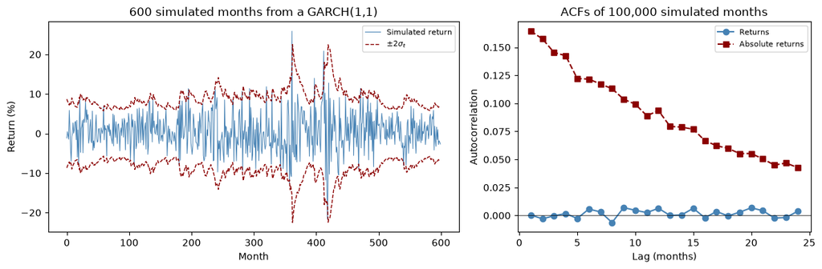

```python
fig, axes = plt.subplots(1, 2, figsize=(12, 4), gridspec_kw={'width_ratios': [1.4, 1]})
axes[0].plot(r_sim[:600], color='steelblue', linewidth=0.7, label='Simulated return')
axes[0].plot(2 * vol_sim[:600], color='darkred', linestyle='--', linewidth=1, label=r'$\pm 2\sigma_t$')
axes[0].plot(-2 * vol_sim[:600], color='darkred', linestyle='--', linewidth=1)
axes[0].set_title("600 simulated months from a GARCH(1,1)")
axes[0].set_xlabel("Month")
axes[0].set_ylabel("Return (%)")
axes[0].legend(loc='upper right', fontsize=8)

lags = np.arange(1, 25)
acf_r = sm.tsa.acf(r_sim, nlags=24)[1:]
acf_abs = sm.tsa.acf(np.abs(r_sim), nlags=24)[1:]
axes[1].plot(lags, acf_r, marker='o', color='steelblue', label='Returns')
axes[1].plot(lags, acf_abs, marker='s', linestyle='--', color='darkred', label='Absolute returns')
axes[1].axhline(0, color='black', linewidth=0.5)
axes[1].set_title("ACFs of 100,000 simulated months")
axes[1].set_xlabel("Lag (months)")
axes[1].set_ylabel("Autocorrelation")
axes[1].legend(fontsize=8)
plt.tight_layout()
plt.show()
```

The sample variance matches the formula $\omega/(1-\alpha-\beta)$ closely. The left panel shows the simulated returns along with $\pm 2\sigma_t$ bands: calm stretches alternate with turbulent ones, and the bands widen right after large shocks and then gradually narrow -- volatility clustering, generated by a model with only three variance parameters. The right panel shows that the simulated returns are essentially uncorrelated, while the absolute returns are positively autocorrelated and decay slowly. The simulated autocorrelations of absolute returns are somewhat smaller than in the real data, but the qualitative pattern is the same: a GARCH(1,1) reproduces the key feature we found in the monthly stock market data.

## Estimating GARCH Models: Beyond OLS

To use a GARCH(1,1) model on real data, we need estimates of $\mu$, $\omega$, $\alpha$, and $\beta$. It is tempting to run a regression of $\sigma^2_t$ on $\epsilon^2_{t-1}$ and $\sigma^2_{t-1}$. The problem is that the dependent variable and one of the regressors are *unobserved*: we never see $\sigma^2_t$, only the returns it generates. Conditional variance is a *latent* (hidden) variable. Instead, GARCH models are estimated by **maximum likelihood**.

The idea is conceptually simple. Pick any candidate values for the parameters. Given those values and the observed returns, we can compute the whole path of conditional variances $\sigma^2_1, \sigma^2_2, \ldots, \sigma^2_T$ recursively from the GARCH equation, starting from some initial value. The model then says each return is normally distributed with mean $\mu$ and variance $\sigma^2_t$, so we can compute how probable ("likely") the observed sample of returns is under those parameter values. The **maximum likelihood estimates** are the parameter values that make the observed data most likely. Intuitively, good parameter values are ones under which the model predicted high variance in the months that turned out to have large returns, and low variance in the months that turned out to be calm.

Unlike OLS, there is no formula for the maximum likelihood estimates of a GARCH model: they have to be found by a *numerical optimizer*, an algorithm that tries a sequence of parameter values, moving "uphill" on the likelihood until it can't improve further. The `arch` package does all of this for us. (The appendix writes down the likelihood and estimates the model "by hand," and confirms we get the same answer.)

The code below fits a GARCH(1,1) with a constant mean to the full 1926-2024 sample of monthly excess returns. The model specification -- constant mean, GARCH(1,1) variance, normal shocks -- is the `arch_model` default. (The `arch` package works best with returns in percent rather than decimals, which is why we converted them.)

```python
garch_full = arch_model(r, mean='Constant', vol='GARCH', p=1, q=1, dist='normal').fit(disp='off')
print(garch_full.summary())
```

```
                     Constant Mean - GARCH Model Results
==============================================================================
Dep. Variable:                  exret   R-squared:                       0.000
Mean Model:             Constant Mean   Adj. R-squared:                  0.000
Vol Model:                      GARCH   Log-Likelihood:               -3487.98
Distribution:                  Normal   AIC:                           6983.97
Method:            Maximum Likelihood   BIC:                           7004.29
                                        No. Observations:                 1188
Date:                Wed, Oct 21 2026   Df Residuals:                     1187
Time:                        12:03:53   Df Model:                            1
                               Mean Model
========================================================================
                 coef    std err          t      P>|t|  95.0% Conf. Int.
------------------------------------------------------------------------
mu             0.8095      0.120      6.734  1.646e-11 [  0.574,  1.045]
                             Volatility Model
==========================================================================
                 coef    std err          t      P>|t|    95.0% Conf. Int.
--------------------------------------------------------------------------
omega          0.7034      0.255      2.754  5.890e-03   [  0.203,  1.204]
alpha[1]       0.1411  2.307e-02      6.116  9.604e-10 [9.589e-02,  0.186]
beta[1]        0.8379  2.320e-02     36.119 1.154e-285   [  0.792,  0.883]
==========================================================================

Covariance estimator: robust
```

```python
def garch_implied(res, periods_per_year=12):
    #Persistence, unconditional (annualized) volatility, and half-life implied by a GARCH(1,1) fit
    p = res.params
    persistence = p['alpha[1]'] + p['beta[1]']
    uncond_vol = np.sqrt(periods_per_year * p['omega'] / (1 - persistence))
    half_life = np.log(0.5) / np.log(persistence)
    return persistence, uncond_vol, half_life

persistence, uncond_vol, half_life = garch_implied(garch_full)
print(f"Persistence alpha + beta:          {persistence:.3f}")
print(f"Implied unconditional volatility:  {uncond_vol:.1f}% per year")
print(f"Sample volatility (annualized):    {np.sqrt(12) * r.std():.1f}% per year")
```

```
Persistence alpha + beta:          0.979
Implied unconditional volatility:  20.0% per year
Sample volatility (annualized):    18.7% per year
```

### Digesting the output

The output is split into a "Mean Model" block (the estimate of $\mu$, labeled `mu`, in percent per month) and a "Volatility Model" block with $\omega$, $\alpha$ (`alpha[1]`), and $\beta$ (`beta[1]`). The estimates have the same layout as OLS output: coefficients, standard errors, $t$-statistics, $p$-values, and confidence intervals.

- The estimate of $\alpha$ is around 0.14 and the estimate of $\beta$ is around 0.84. Both have very large $t$-statistics, so we can firmly reject the null hypothesis of constant conditional variance ($\alpha = \beta = 0$), which is the hypothesis of no volatility clustering at all.
- The persistence $\alpha + \beta$ is about 0.98 -- just under one. Since this is the volatility counterpart of the AR(1) slope, the conditional variance is highly persistent: shocks to volatility die out, but slowly.
- The implied unconditional volatility $\sqrt{12\,\omega/(1-\alpha-\beta)}$ is about 20% per year, a little above the sample volatility. The two needn't match exactly, since the former is a function of three estimated parameters that are pinned down by the *dynamics* of the data, not just its average squared deviation. Note that with persistence this close to one, the denominator $1-\alpha-\beta$ is small, so the implied unconditional volatility is quite sensitive to small changes in the estimates.

Given the parameter estimates, `arch` computes the fitted conditional volatility $\hat\sigma_t$ for every month using the GARCH recursion. It also computes the **standardized residuals** $\hat e_t = (r_t - \hat\mu)/\hat\sigma_t$: each month's return surprise, divided by the volatility the model expected. If the model has captured the volatility dynamics, the standardized residuals should look like the iid $N(0,1)$ draws $e_t$ the model assumes -- in particular, they should show *no* volatility clustering. The code below plots both series.

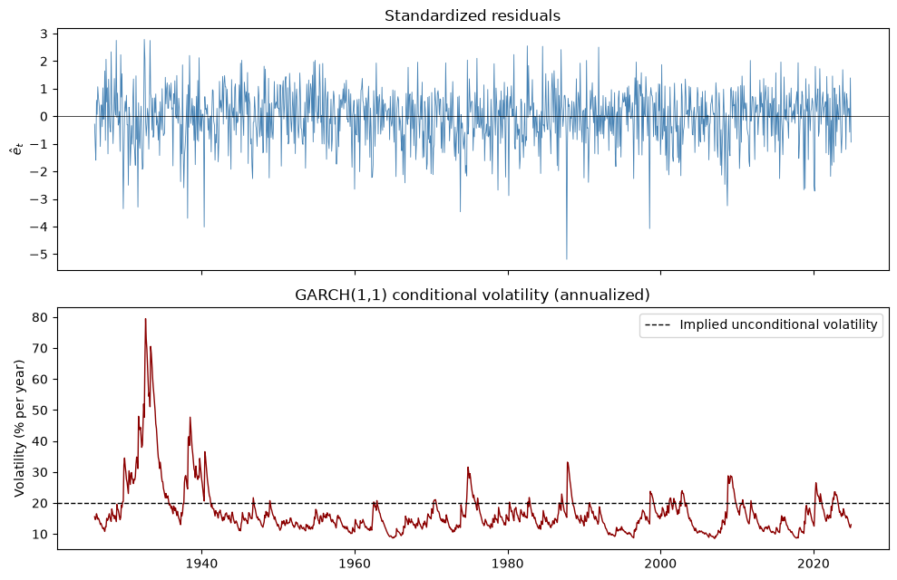

```
Highest conditional volatility: 79% per year, in September 1932
Lowest conditional volatility:  9% per year, in February 2007
```

```python
cond_vol_ann = np.sqrt(12) * garch_full.conditional_volatility     #annualized conditional volatility
std_resid = garch_full.std_resid

fig, axes = plt.subplots(2, 1, figsize=(10, 6.5), sharex=True)
axes[0].plot(std_resid.index, std_resid, color='steelblue', linewidth=0.6)
axes[0].axhline(0, color='black', linewidth=0.5)
axes[0].set_title("Standardized residuals")
axes[0].set_ylabel(r"$\hat{e}_t$")
axes[1].plot(cond_vol_ann.index, cond_vol_ann, color='darkred', linewidth=1)
axes[1].axhline(uncond_vol, color='black', linestyle='--', linewidth=1, label='Implied unconditional volatility')
axes[1].set_title("GARCH(1,1) conditional volatility (annualized)")
axes[1].set_ylabel("Volatility (% per year)")
axes[1].legend(loc='upper right')
plt.tight_layout()
plt.show()

print(f"Highest conditional volatility: {cond_vol_ann.max():.0f}% per year, in {cond_vol_ann.idxmax():%B %Y}")
print(f"Lowest conditional volatility:  {cond_vol_ann.min():.0f}% per year, in {cond_vol_ann.idxmin():%B %Y}")
```

### Comments on the figure

1. The conditional volatility (bottom panel) is much smoother than the absolute returns we plotted earlier. That is by design: the GARCH variance is a slowly declining weighted average of past squared shocks, so it smooths out month-to-month noise.
2. The time variation in conditional volatility is *economically* enormous, not just statistically significant. During the Great Depression, the model's conditional volatility peaked at around 80% per year. In calm periods, it falls below 10% per year -- and its lowest point in the whole sample was in early 2007, right before the financial crisis, a reminder that a volatility model forecasts the *typical* size of the next shock, not the arrival of a crisis.
3. The standardized residuals (top panel) look much more homogeneous over time than the raw returns: the turbulent periods no longer stand out. There are still a few large negative values, most notably the October 1987 crash, which came out of a calm period and so was a huge surprise relative to the volatility the model expected.

We can check point 3 more formally with the Ljung-Box test from `TimeSeries.ipynb`, applied to *absolute* values. If the GARCH model has captured the volatility clustering, the absolute standardized residuals should show no autocorrelation, even though the absolute returns themselves show a lot.

```python
lb = pd.DataFrame({
    'Absolute returns': acorr_ljungbox(r.abs(), lags=[12]).iloc[0],
    'Absolute standardized residuals': acorr_ljungbox(std_resid.abs(), lags=[12]).iloc[0],
}).T
lb.columns = ['Ljung-Box Q (12 lags)', 'p-value']
print(lb.round(3))
```

```
                                 Ljung-Box Q (12 lags)  p-value
Absolute returns                               701.759     0.00
Absolute standardized residuals                  8.443     0.75
```

The Ljung-Box statistic for absolute returns is enormous, rejecting "no autocorrelation" at any conventional level. For the absolute standardized residuals it is small, with a $p$-value well above 5%. So, by this test, the GARCH(1,1) has soaked up essentially all of the volatility clustering in monthly stock returns -- a striking result for a model with three variance parameters.

### Does the Great Depression drive the results?

The Great Depression produced by far the most extreme volatility in the sample. To see how much it influences the estimates, the code below re-fits the model using only post-World War II data, from 1945 onward.

```python
r_post = r.loc['1945':]
garch_post = arch_model(r_post).fit(disp='off')    #same specification: constant mean, GARCH(1,1), normal
print(garch_post.params.round(4).to_string())

summary = pd.DataFrame([garch_implied(garch_full), garch_implied(garch_post)],
                       index=['1926-2024', '1945-2024'],
                       columns=['Persistence', 'Uncond. vol (% per yr)', 'Half-life (months)'])
print()
print(summary.round(3))
```

```
mu          0.7688
omega       1.0166
alpha[1]    0.1243
beta[1]     0.8241

           Persistence  Uncond. vol (% per yr)  Half-life (months)
1926-2024        0.979                  20.040              32.632
1945-2024        0.948                  15.365              13.065
```

The post-war estimates of $\alpha$ and $\beta$ are both a bit smaller, so the persistence falls from about 0.98 to about 0.95, and the implied unconditional volatility falls from about 20% to about 15% per year. The persistence numbers can be made more concrete with the **half-life**: the number of periods it takes for half of a shock to volatility to die out, $\ln(0.5)/\ln(\alpha + \beta)$, which solves $(\alpha+\beta)^h = 0.5$ for $h$ (we will see in the next section why the gap between the variance and its long-run level shrinks by a factor of $\alpha + \beta$ each period). It is over two years in the full sample, but about a year in the post-war sample. The Great Depression, a long stretch of extremely high volatility, makes volatility look more persistent than it has been since. The basic message is unchanged, though: volatility is highly persistent and strongly time-varying in both samples. We use the post-war model for forecasting below.

## Forecasting Volatility with GARCH Models

Once the parameters are estimated, a GARCH model delivers forecasts of future volatility almost for free. Suppose the sample ends at month $T$. The one-step-ahead forecast of the variance is just the GARCH equation, evaluated with the last estimated shock and conditional variance:

$$\hat\sigma^2_{T+1} = \hat\omega + \hat\alpha\,\hat\epsilon^2_{T} + \hat\beta\,\hat\sigma^2_{T}.$$

Everything on the right-hand side is known at time $T$, so this is an exact forecast of next month's conditional variance (up to estimation error in the parameters).

### Forecasting further ahead

For two or more months ahead, we need the *expected* conditional variance, since future shocks aren't known yet. Write $E_T[\cdot]$ for an expectation conditional on information at time $T$. For any future month $T+j$ with $j \ge 1$, the expected squared shock equals the expected conditional variance, because $E_T[\epsilon^2_{T+j}] = E_T[\sigma^2_{T+j}\, e^2_{T+j}] = E_T[\sigma^2_{T+j}] \times 1$ (the standard normal $e_{T+j}$ is independent of $\sigma^2_{T+j}$ and has $E[e^2] = 1$). So taking $E_T$ of both sides of the GARCH equation for $\sigma^2_{T+j+1}$ gives

$$E_T[\sigma^2_{T+j+1}] = \omega + \alpha E_T[\epsilon^2_{T+j}] + \beta E_T[\sigma^2_{T+j}] = \omega + (\alpha + \beta)\,E_T[\sigma^2_{T+j}].$$

Now subtract the unconditional variance $\sigma^2 = \omega/(1-\alpha-\beta)$ from both sides. Since $\omega = (1 - \alpha - \beta)\sigma^2$, the right-hand side becomes $(1-\alpha-\beta)\sigma^2 + (\alpha+\beta)E_T[\sigma^2_{T+j}] - \sigma^2 = (\alpha+\beta)\big(E_T[\sigma^2_{T+j}] - \sigma^2\big)$, so

$$E_T[\sigma^2_{T+j+1}] - \sigma^2 = (\alpha + \beta)\,\big(E_T[\sigma^2_{T+j}] - \sigma^2\big).$$

In words: the gap between the variance forecast and the long-run variance shrinks by a factor of $\alpha + \beta$ with each additional month. Applying this $h - 1$ times, starting from the one-step forecast, gives the $h$-step-ahead forecast

$$E_T[\sigma^2_{T+h}] = \sigma^2 + (\alpha+\beta)^{h-1}\big(\sigma^2_{T+1} - \sigma^2\big).$$

This is exactly the pattern of AR(1) forecasts in `TimeSeries.ipynb`, with persistence $\alpha + \beta$ playing the role of $\phi$: variance forecasts revert geometrically to the long-run variance. If volatility is currently high, the model forecasts that it will gradually decline; if it is currently low, the model forecasts a gradual rise.

The `forecast` method in `arch` computes these forecasts. The code below computes them for the next 36 months from the post-war model, checks them against the formula above, and converts the variance forecasts into annualized volatility forecasts.

```python
H = 36
fc = garch_post.forecast(horizon=H)
var_fc = fc.variance.iloc[-1].values                  #monthly variance forecasts, horizons 1..H

#Check against the formula, computed by hand from the estimated parameters
p = garch_post.params
persistence_post = p['alpha[1]'] + p['beta[1]']
sig2_bar = p['omega'] / (1 - persistence_post)
sig2_next = p['omega'] + p['alpha[1]'] * garch_post.resid.iloc[-1]**2 + p['beta[1]'] * garch_post.conditional_volatility.iloc[-1]**2
h = np.arange(1, H + 1)
var_by_hand = sig2_bar + persistence_post**(h - 1) * (sig2_next - sig2_bar)
print(f"Largest gap between arch's forecasts and the formula: {np.max(np.abs(var_fc - var_by_hand)):.2e}")

vol_fc = np.sqrt(12 * var_fc)                         #annualized volatility forecasts
print(f"\nConditional volatility at the end of the sample ({r_post.index[-1]:%b %Y}): "
      f"{np.sqrt(12) * garch_post.conditional_volatility.iloc[-1]:.1f}% per year")
print(f"Long-run (unconditional) volatility: {np.sqrt(12 * sig2_bar):.1f}% per year")
print(pd.Series(vol_fc, index=h, name='Forecast vol (% per yr)').loc[[1, 3, 6, 12, 24, 36]].round(1).to_string())
```

```
Largest gap between arch's forecasts and the formula: 7.11e-15

Conditional volatility at the end of the sample (Dec 2024): 12.8% per year
Long-run (unconditional) volatility: 15.4% per year
1     12.8
3     13.1
6     13.5
12    14.0
24    14.7
36    15.0
```

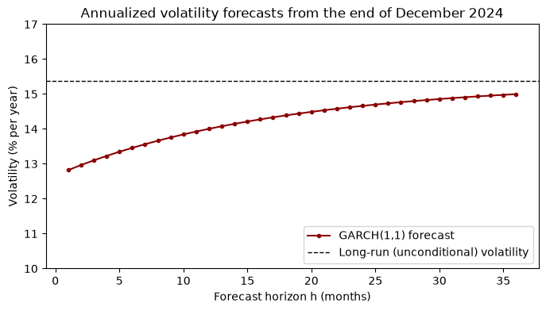

```python
fig, ax = plt.subplots(figsize=(8, 4))
ax.plot(h, vol_fc, marker='o', markersize=3, color='darkred', label='GARCH(1,1) forecast')
ax.axhline(np.sqrt(12 * sig2_bar), color='black', linestyle='--', linewidth=1,
           label='Long-run (unconditional) volatility')
ax.set_title(f"Annualized volatility forecasts from the end of {r_post.index[-1]:%B %Y}")
ax.set_xlabel("Forecast horizon h (months)")
ax.set_ylabel("Volatility (% per year)")
ax.set_ylim(10, 17)
ax.legend(loc='lower right')
plt.show()
```

The `arch` forecasts match the formula to many decimal places. At the end of 2024, the model's conditional volatility was around 13% per year, *below* its long-run level of around 15%, because the stock market had been relatively calm through most of 2023 and 2024. So the model forecasts volatility to rise gradually back toward its long-run level, closing about half the gap in roughly a year (the half-life from the table above).

As the April 2025 episode showed, this forecast turned out to be much too low a few months later. That isn't a failure of the model so much as a reminder of what it does: it forecasts the *expected* level of volatility given the past, and the tariff shock was news that nobody had in the information set at the end of 2024. After such a shock arrives, a GARCH model quickly raises its forecasts.

## Realized Volatility

GARCH models infer volatility indirectly, from a model of how returns behave. A second approach, which has become the standard whenever high-frequency data are available, is to *measure* volatility directly: **realized volatility**.

The key idea is simple. To estimate the variance of returns over some interval, such as a trading day, *add up the squared returns over many short sub-intervals within it*. Suppose we observe the log price at $m+1$ evenly spaced times during day $t$, giving $m$ intraday returns $r_{1,t}, r_{2,t}, \ldots, r_{m,t}$ (for example, $m = 78$ five-minute returns in a 6.5-hour trading day). The **realized variance** for day $t$ is

$$RV_t = \sum_{i=1}^{m} r_{i,t}^2,$$

and the **realized volatility** is its square root, $\sqrt{RV_t}$.

Notice that there is no mean subtracted. Over intervals as short as five minutes, the expected return is so tiny compared with the typical size of a return that ignoring it makes essentially no difference. Notice also that there is no model here -- no parameters to estimate and no assumption about how volatility evolves. RV is a *nonparametric* measure.

### Why sampling more often helps

Why should this work? Think about estimating the variance of a day's return from a single observation: the daily return squared. That is an unbiased but very noisy estimate -- a day that happens to end near where it started gives a squared return near zero, even if prices swung wildly during the day. Splitting the day into $m$ pieces and adding up the squared pieces is like averaging $m$ noisy estimates instead of relying on one, and the noise shrinks as $m$ grows.

More formally (this is stated without proof, as it relies on mathematics beyond this course): if prices move continuously and volatility $\sigma_s$ changes over the course of the day, then as $m \to \infty$,

$$RV_t \;\longrightarrow\; \int_{t-1}^{t} \sigma^2_s \, ds.$$

The right-hand side, called the **integrated variance**, is the total amount of return variance that actually occurred over the day -- the "sum" of the instantaneous variance at every moment. So with finely sampled data, RV recovers the day's actual return variation essentially without error, even though volatility was changing during the day.

### Verifying by simulation

We can check this claim directly. The code below simulates 2,000 trading days, each with a randomly drawn level of volatility and a U-shaped intraday pattern (volatility is highest near the open and close, as in real markets), so each day's integrated variance is known. For each day, it computes RV from returns sampled once a day ($m = 1$), every 30 minutes ($m = 13$), every 5 minutes ($m = 78$), and every minute ($m = 390$), and compares each with the true integrated variance.

```python
rng = np.random.default_rng(14)
n_days, n_sec = 2000, 23_400                          #a 6.5-hour trading day = 23,400 seconds
u = np.linspace(0, 1, n_sec)
intraday_shape = 1 + 1.5 * (u - 0.5)**2 / 0.25        #U-shape: 2.5x as volatile at the open and close as at midday
intraday_shape /= intraday_shape.mean()

daily_var = rng.lognormal(mean=np.log(1.0), sigma=0.5, size=n_days)   #each day's variance (%^2)
inst_var = daily_var[:, None] * intraday_shape[None, :] / n_sec       #variance of each one-second return
integrated_var = inst_var.sum(axis=1)                                 #the true daily integrated variance

sec_returns = np.sqrt(inst_var) * rng.standard_normal((n_days, n_sec))
log_price = np.cumsum(sec_returns, axis=1)
log_price = np.hstack([np.zeros((n_days, 1)), log_price])             #start each day at 0

rv_by_m = {}
for m in [1, 13, 78, 390]:
    step = n_sec // m
    intraday_rets = np.diff(log_price[:, ::step], axis=1)             #m returns per day
    rv_by_m[m] = (intraday_rets**2).sum(axis=1)

errors = pd.DataFrame({f"m = {m}": rv - integrated_var for m, rv in rv_by_m.items()})
print("RV minus integrated variance, across 2,000 simulated days:")
print(errors.describe().loc[['mean', 'std']].round(3))
```

```
RV minus integrated variance, across 2,000 simulated days:
      m = 1  m = 13  m = 78  m = 390
mean -0.038   0.000  -0.000   -0.001
std   1.746   0.535   0.209    0.096
```

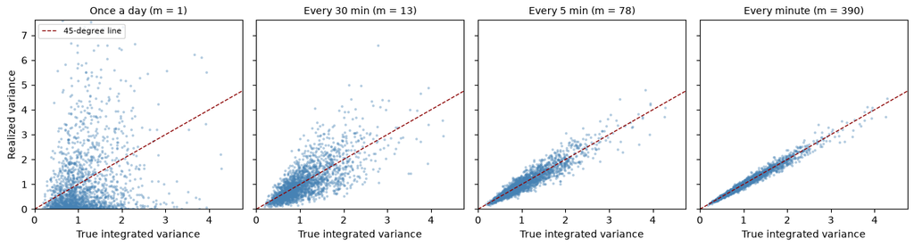

```python
fig, axes = plt.subplots(1, 4, figsize=(13, 3.6), sharex=True, sharey=True)
labels = {1: 'Once a day', 13: 'Every 30 min', 78: 'Every 5 min', 390: 'Every minute'}
lim = np.percentile(integrated_var, 99.5) * 1.3
for ax, (m, rv) in zip(axes, rv_by_m.items()):
    ax.scatter(integrated_var, rv, s=3, alpha=0.3, color='steelblue')
    ax.plot([0, lim], [0, lim], color='darkred', linestyle='--', linewidth=1, label='45-degree line')
    ax.set_title(f"{labels[m]} (m = {m})", fontsize=10)
    ax.set_xlabel("True integrated variance")
axes[0].set_ylabel("Realized variance")
axes[0].set_xlim(0, lim)
axes[0].set_ylim(0, lim * 1.6)
axes[0].legend(loc='upper left', fontsize=8)
plt.tight_layout()
plt.show()
```

In every case the average error is close to zero: RV is (approximately) unbiased no matter how often we sample. But the *precision* differs enormously. With one return per day, RV is all over the place -- many days with a large true variance produce a squared daily return near zero. With 30-minute returns the points start to line up along the 45-degree line, and with 5-minute or 1-minute returns RV tracks the true integrated variance closely. The standard deviation of the error falls roughly in proportion to $1/\sqrt{m}$, just like the standard error of a sample mean.

In real data there is a limit to this: at very high frequencies (individual trades, or every few seconds), prices bounce between the bid and the ask, and these "microstructure" effects add noise that *grows* with $m$. Five-minute returns are a popular compromise between precision and microstructure noise, and that is what we use next.

### Realized volatility of S&P 500 futures

Our data are 5-minute prices for the E-mini S&P 500 futures contract, from March 2015 through August 2017. E-mini futures trade nearly around the clock, and are among the most liquid financial contracts in the world; their price tracks the S&P 500 index very closely. The file includes 5-minute log returns, in decimals.

We keep only regular U.S. trading hours (9:30 am to 4:00 pm Eastern), when trading is most active. That gives the 78 five-minute returns ending at 9:35, 9:40, ..., 4:00 on a normal trading day. Overnight returns are excluded, so our RV measures variation *during the trading day* only.

```python
#5-minute E-mini S&P 500 futures data, March 2015 - August 2017 (see Instructions to Run)
es = pd.read_csv("../data/emini_sp500_5min.csv", parse_dates=["datetime"]).set_index("datetime")
print(es.head(3))

#Keep the 78 five-minute returns ending 9:35 through 16:00 (regular trading hours)
tod = es.index.time
rth = es[(tod > pd.Timestamp('09:30').time()) & (tod <= pd.Timestamp('16:00').time())].copy()
rth['day'] = rth.index.normalize()

print(f"\nTrading days: {rth['day'].nunique()}")
print("Number of 5-minute returns per day (a few early-close holiday sessions have fewer):")
print(rth.groupby('day').size().value_counts().to_string())
```

```
                       close       ret
datetime
2015-03-13 00:00:00  2059.25  0.000000
2015-03-13 00:05:00  2058.25 -0.000486
2015-03-13 00:10:00  2058.25  0.000000

Trading days: 624
Number of 5-minute returns per day (a few early-close holiday sessions have fewer):
78    620
44      3
42      1
```

```python
#Daily realized variance: the sum of squared 5-minute returns. Scale by 100^2 so it is in percent^2
rv = pd.DataFrame({'RVar': 100**2 * (rth['ret']**2).groupby(rth['day']).sum()})
rv['RVol'] = np.sqrt(rv['RVar'])                      #daily realized volatility, in percent
rv['AnnRVol'] = np.sqrt(252) * rv['RVol']             #annualized, in percent per year
print(rv.describe().round(2))
```

```
         RVar    RVol  AnnRVol
count  624.00  624.00   624.00
mean     0.39    0.53     8.47
std      0.93    0.33     5.19
min      0.01    0.08     1.25
25%      0.12    0.34     5.47
50%      0.21    0.46     7.26
75%      0.39    0.62     9.88
max     20.31    4.51    71.53
```

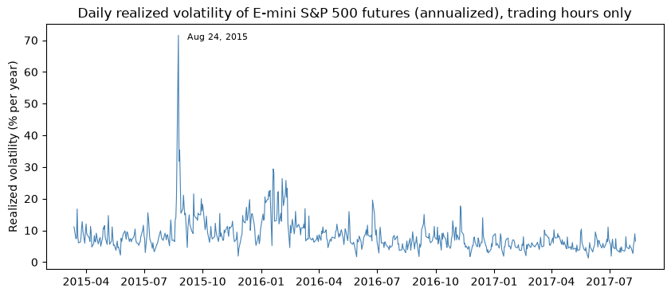

```python
fig, ax = plt.subplots(figsize=(10, 4))
ax.plot(rv.index, rv['AnnRVol'], color='steelblue', linewidth=0.8)
peak = rv['AnnRVol'].idxmax()
ax.annotate(f"{peak:%b %d, %Y}", (peak, rv['AnnRVol'].max()), textcoords='offset points',
            xytext=(8, -4), fontsize=8)
ax.set_title("Daily realized volatility of E-mini S&P 500 futures (annualized), trading hours only")
ax.set_ylabel("Realized volatility (% per year)")
plt.show()
```

The realized volatility series shows the same features as the GARCH conditional volatility, but now at the daily frequency and measured directly, without a model. There are calm stretches where trading-hours RV runs well under 10% per year (much of 2017 was famously quiet), and turbulent episodes, the most extreme of which is August 24, 2015. On that morning, after a sharp sell-off in China, U.S. stocks opened with a plunge -- the Dow fell about 1,000 points in the first few minutes of trading -- and realized volatility for that day was roughly ten times its typical level. The high RV persisted for days afterward, and there is a second turbulent period in early 2016.

Two cautions when comparing these numbers with the GARCH estimates earlier. First, because overnight returns are excluded, trading-hours RV understates the total variability of daily returns. Second, these 2.5 years were a relatively calm stretch for the market, so the typical level of RV here is lower than the long-run averages we found earlier.

## Modeling and Forecasting Realized Volatility

Because RV is (approximately) *observed*, we can model it with the ordinary time-series tools from `TimeSeries.ipynb`. This is a big practical advantage over GARCH: no latent variables, no maximum likelihood, no numerical optimization -- just AR-type regressions estimated by OLS. We model daily realized *volatility* (`RVol`, the square root of RV, in percent per day), which is in more interpretable units than realized variance and has fewer extreme outliers.

First, how persistent is it?

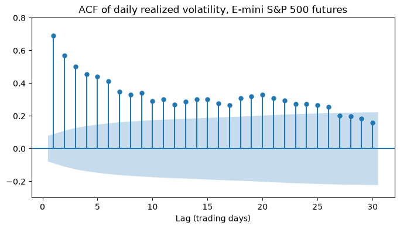

```python
rvol = rv['RVol'].reset_index(drop=True)              #a plain 0, 1, 2, ... index: one row per trading day

fig, ax = plt.subplots(figsize=(8, 4))
sm.graphics.tsa.plot_acf(rvol, lags=30, zero=False, ax=ax,
                         title="ACF of daily realized volatility, E-mini S&P 500 futures")
ax.set_xlabel("Lag (trading days)")
ax.set_ylim(-0.3, 0.8)
plt.show()
```

Realized volatility is highly persistent: the lag-1 autocorrelation is around 0.7, and the autocorrelations decline only slowly, staying outside the bands for more than a month (about 25 trading days).

### A random-walk volatility forecast

The high persistence suggests a very simple forecast: tomorrow's realized volatility will be about the same as today's,

$$\widehat{RVol}_{t+1} = RVol_t.$$

This "random walk" forecast is easy to compute and often hard to beat. As we saw in `TimeSeries.ipynb`, setting the forecast equal to the current value is optimal if the series is a random walk (has a unit root). But the ACF does die out, which suggests realized volatility is stationary, and that forecasts should revert toward the long-run mean rather than staying put. Let's fit an AR(1).

```python
ar1 = AutoReg(rvol, lags=1).fit()
print(ar1.summary())

phi, se_phi = ar1.params.iloc[1], ar1.bse.iloc[1]
print(f"\nt-statistic for H0: phi = 1  ->  ({phi:.3f} - 1) / {se_phi:.3f} = {(phi - 1) / se_phi:.1f}")
```

```
                            AutoReg Model Results
==============================================================================
Dep. Variable:                   RVol   No. Observations:                  624
Model:                     AutoReg(1)   Log Likelihood                  15.107
Method:               Conditional MLE   S.D. of innovations              0.236
Date:                Wed, 21 Oct 2026   AIC                            -24.214
Time:                        12:03:56   BIC                            -10.910
Sample:                             1   HQIC                           -19.044
                                  624
==============================================================================
                 coef    std err          z      P>|z|      [0.025      0.975]
------------------------------------------------------------------------------
const          0.1645      0.018      9.076      0.000       0.129       0.200
RVol.L1        0.6910      0.029     23.868      0.000       0.634       0.748
                                    Roots
=============================================================================
                  Real          Imaginary           Modulus         Frequency
-----------------------------------------------------------------------------
AR.1            1.4471           +0.0000j            1.4471            0.0000
-----------------------------------------------------------------------------

t-statistic for H0: phi = 1  ->  (0.691 - 1) / 0.029 = -10.7
```

### AR(1) interpretation

The slope on yesterday's realized volatility is around 0.7, essentially the same as the lag-1 autocorrelation (as it should be, from `TimeSeries.ipynb`). It is far from one: the $t$-statistic for the null hypothesis $\phi = 1$ is below $-10$. (Strictly, under a unit root the usual $t$-statistic doesn't have a standard normal distribution, but a value this extreme rejects under the appropriate Dickey-Fuller critical values too.) So realized volatility looks stationary, and the AR(1) forecast

$$\widehat{RVol}_{t+1} = \hat c + \hat\phi\, RVol_t$$

pulls tomorrow's forecast part of the way from today's value back toward the long-run mean, rather than leaving it at today's value.

But the ACF decays more slowly than the geometric pattern $\phi^j$ of an AR(1): with $\hat\phi \approx 0.7$, an AR(1) implies an autocorrelation of about $0.7^{10} \approx 0.03$ at lag 10, but the sample ACF there is still around 0.3. Perhaps more lags would help.

### How many lags?

```python
ar2 = AutoReg(rvol, lags=2).fit()
print(ar2.params.round(3).to_string())
print(f"\nt-statistics:\n{ar2.tvalues.round(1).to_string()}")

#Lag length chosen by each information criterion, searching up to 22 lags (about a month of trading days)
print("\nLags selected (max 22):")
for ic in ['bic', 'hqic', 'aic']:
    print(f"  {ic.upper():5s} -> AR({len(ar_select_order(rvol, maxlag=22, ic=ic).ar_lags)})")
```

```
const      0.136
RVol.L1    0.570
RVol.L2    0.175

t-statistics:
const       7.1
RVol.L1    14.4
RVol.L2     4.4

Lags selected (max 22):
  BIC   -> AR(2)
  HQIC  -> AR(5)
  AIC   -> AR(18)
```

In an AR(2), *both* lags are highly significant. Asking the information criteria from `TimeSeries.ipynb` to choose the lag length, the three criteria disagree sharply: BIC, which penalizes extra parameters most heavily, picks a short model, while HQIC picks a longer one and AIC a much longer one still. When different reasonable criteria pick lag lengths this different, it is a sign that the persistence in the series has a complicated shape -- a quick initial decline followed by a long, slow tail -- that a short AR model can't capture and a long one captures only by estimating a lot of parameters.

### The HAR model

A popular way to capture this "long memory" without a long list of lags is the **heterogeneous autoregressive (HAR) model** of Corsi (2009). It regresses tomorrow's realized volatility on three averages of past realized volatility: yesterday's value, the average over the past week (5 trading days), and the average over the past month (22 trading days):

$$RVol_{t+1} = c + \beta_d\, RVol_t + \beta_w\, \overline{RVol}_{t}^{(w)} + \beta_m\, \overline{RVol}_{t}^{(m)} + u_{t+1},$$

where $\overline{RVol}_{t}^{(w)} = \frac{1}{5}\sum_{j=0}^{4} RVol_{t-j}$ and $\overline{RVol}_{t}^{(m)} = \frac{1}{22}\sum_{j=0}^{21} RVol_{t-j}$.

The economic story behind it is that markets contain traders with different horizons -- day traders, weekly rebalancers, and longer-term investors -- each reacting to volatility at their own horizon. The statistical point is simpler: the HAR is an AR(22) whose 22 slopes are restricted to a simple step pattern (a large weight on the most recent day, a smaller weight on days 2 to 5, and a still smaller weight on days 6 to 22), so it captures slowly decaying persistence with only four parameters. And since it is just a linear regression, we estimate it by OLS.

```python
#Build the HAR regressors. Row t holds information known at the end of day t; the target is day t+1
har = pd.DataFrame({'RVol_next': rvol.shift(-1),
                    'RVol_d': rvol,
                    'RVol_w': rvol.rolling(5).mean(),
                    'RVol_m': rvol.rolling(22).mean()}).dropna()

har_fit = sm.OLS(har['RVol_next'], sm.add_constant(har[['RVol_d', 'RVol_w', 'RVol_m']])).fit()
print(har_fit.summary().tables[1])
print(f"R-squared: {har_fit.rsquared:.3f}")
```

```
==============================================================================
                 coef    std err          t      P>|t|      [0.025      0.975]
------------------------------------------------------------------------------
const          0.0584      0.025      2.347      0.019       0.010       0.107
RVol_d         0.4879      0.046     10.652      0.000       0.398       0.578
RVol_w         0.2004      0.070      2.856      0.004       0.063       0.338
RVol_m         0.2002      0.068      2.953      0.003       0.067       0.333
==============================================================================
R-squared: 0.521
```

All three components are statistically significant: the daily term gets the largest weight, but the weekly and monthly averages carry information beyond what yesterday's value contains. The HAR forecast puts weight on volatility over the past month as well as yesterday, which is how it captures the slow decay in the ACF.

### Which forecast works best out of sample?

In-sample fit can be misleading, as we saw in `PredictiveRegressions.ipynb`, so we compare forecasts the same way we did there: **out of sample**, using an expanding estimation window. Starting after the first 250 trading days (about a year), for each day $t$ we re-estimate each model using only data through day $t$, forecast $RVol_{t+1}$, and record the squared forecast error. We compare four forecasts:

1. **Historical mean**: the average realized volatility to date (ignores persistence entirely).
2. **Random walk**: $\widehat{RVol}_{t+1} = RVol_t$.
3. **AR(1)**.
4. **HAR**.

To keep the comparison apples-to-apples, all four use the same rows, so the AR(1) is estimated by OLS on the same `har` data frame (regressing `RVol_next` on `RVol_d` alone).

```python
def ols_forecast(train, test_row, regressors):
    #Fit OLS of RVol_next on `regressors` using `train`, and forecast for `test_row`
    fit = sm.OLS(train['RVol_next'], sm.add_constant(train[regressors])).fit()
    return fit.params['const'] + test_row[regressors] @ fit.params[regressors]

start = 250
forecasts = {'Historical mean': [], 'Random walk': [], 'AR(1)': [], 'HAR': []}
for i in range(start, len(har)):
    train, test_row = har.iloc[:i], har.iloc[i]
    forecasts['Historical mean'].append(train['RVol_next'].mean())
    forecasts['Random walk'].append(test_row['RVol_d'])
    forecasts['AR(1)'].append(ols_forecast(train, test_row, ['RVol_d']))
    forecasts['HAR'].append(ols_forecast(train, test_row, ['RVol_d', 'RVol_w', 'RVol_m']))

actual = har['RVol_next'].iloc[start:].values
mse = pd.Series({name: np.mean((actual - np.array(f))**2) for name, f in forecasts.items()})
oos = pd.DataFrame({'MSE': mse, 'MSE relative to random walk': mse / mse['Random walk']})
print(f"Out-of-sample forecasts: {len(actual)} trading days")
print(oos.round(4))
```

```
Out-of-sample forecasts: 352 trading days
                    MSE  MSE relative to random walk
Historical mean  0.0623                       2.8469
Random walk      0.0219                       1.0000
AR(1)            0.0215                       0.9842
HAR              0.0181                       0.8296
```

The results line up with everything above:

- The **historical mean** is by far the worst forecast, with a mean squared error several times larger than the others. Ignoring volatility clustering is costly.
- The **random walk** and the **AR(1)** perform about equally well. Partial mean reversion helps a little, but most of the gain over the historical mean comes simply from using today's volatility.
- The **HAR** model has the lowest MSE, beating the random walk by a meaningful margin. Using the past week and month of volatility, not just yesterday's, improves the forecasts.

Keep in mind that this is a single, fairly short sample (about 1.5 years of out-of-sample days), so the precise rankings shouldn't be over-interpreted. But the general pattern -- simple persistence-based forecasts beat the mean by a wide margin, and HAR-type models beat simple persistence -- is one of the most consistent findings in the volatility forecasting literature.

## Takeaways

- **Volatility clusters.** Stock returns have almost no autocorrelation, but their *absolute* values are strongly and persistently autocorrelated: in nearly a century of monthly U.S. data, the autocorrelations of absolute returns are around 0.2 to 0.3 over the first year of lags and remain positive two years out. The sign of the next return is unpredictable, but its size is not -- as the April 2025 tariff shock illustrated in real time.
- **GARCH(1,1) captures this with three parameters.** The conditional variance $\sigma^2_t = \omega + \alpha\epsilon^2_{t-1} + \beta\sigma^2_{t-1}$ is an exponentially weighted average of past squared shocks, with persistence $\alpha + \beta$ and long-run variance $\omega/(1-\alpha-\beta)$. Simulation confirmed that it generates the clustering we see in the data.
- **The estimates imply large, persistent swings in risk.** For monthly stock returns, $\alpha + \beta$ is close to one, conditional volatility ranged from under 10% to around 80% per year, and the standardized residuals showed no remaining volatility clustering by the Ljung-Box test. Excluding the Great Depression lowers the persistence somewhat, but doesn't change the message.
- **GARCH forecasts revert to the long-run variance**, with the gap shrinking by a factor of $\alpha + \beta$ each period -- the same logic as AR(1) forecasts. At the end of 2024 volatility was below its long-run level, so the model forecast a gradual rise.
- **Realized volatility measures volatility directly** by summing squared intraday returns. Simulation showed that sampling more often makes RV far more precise, though in real data microstructure noise limits how high the frequency can usefully go.
- **Because RV is observed, it can be forecast with ordinary regressions.** Daily RV is highly persistent with a slowly decaying ACF. Out of sample, persistence-based forecasts beat the historical mean by a wide margin, and the HAR model, which averages past volatility over a day, a week, and a month, beat both the random walk and the AR(1).

**Where this goes next.** This notebook modeled the volatility of a single asset. Next we move to the *covariance* structure of many assets at once -- principal components and statistical factor models -- where the same questions of estimation, persistence, and forecasting arise in a richer setting. Volatility forecasts are also a natural ingredient for a capstone project: in risk management (Value-at-Risk), in portfolio strategies that scale exposure down when volatility is high, and in comparing model forecasts with option-implied volatility.

## Additional Technical Material

This appendix collects technical details that were stated without proof, or skipped, in the main text above.

### When are the autocorrelations of squared shocks $\alpha^s$?

The main text showed that, under ARCH(1), $\epsilon^2_t$ follows an AR(1) with slope $\alpha$, and then used the AR(1) result that the autocorrelations are $\alpha^s$. That result requires the AR(1) to have a finite variance -- and here the "variance" is the variance of $\epsilon^2_t$, which involves the *fourth* moment of $\epsilon_t$, $E[\epsilon^4_t]$. For an ARCH(1) with normal shocks, $E[\epsilon^4_t]$ is finite only if $3\alpha^2 < 1$, i.e. $\alpha < 0.577$. (If $\alpha$ is between $0.577$ and $1$, the process is still stationary with a finite variance, but its squared values have such fat tails that their autocorrelations aren't defined.) For a GARCH(1,1) with normal shocks, the corresponding condition is $(\alpha + \beta)^2 + 2\alpha^2 < 1$. When it holds, the autocorrelations of $\epsilon^2_t$ decay at the rate $(\alpha + \beta)$ per lag after the first lag. The estimates for monthly stock returns are close to the boundary of this condition, which is one reason sample autocorrelations of squared returns can be erratic, and why we used absolute returns in the main text.

### The GARCH log-likelihood, and estimating it by hand

Under the GARCH(1,1) model, the return $r_t$ is normally distributed with mean $\mu$ and variance $\sigma^2_t$, *conditional* on the past. So the probability density of $r_t$, given the past, is the normal density

$$f(r_t \mid I_{t-1}) = \frac{1}{\sqrt{2\pi\sigma^2_t}} \exp\!\left(-\frac{(r_t - \mu)^2}{2\sigma^2_t}\right).$$

The joint density of the whole sample is the product of these conditional densities, and taking logs turns the product into a sum. The **log-likelihood** is therefore

$$\log L(\mu, \omega, \alpha, \beta) = -\frac{1}{2}\sum_{t=1}^{T}\left[\log(2\pi) + \log\sigma^2_t + \frac{(r_t - \mu)^2}{\sigma^2_t}\right],$$

where each $\sigma^2_t$ is computed recursively from the GARCH equation and the parameters. The two terms inside the brackets show the trade-off the estimator makes: a large $\sigma^2_t$ reduces the penalty $(r_t-\mu)^2/\sigma^2_t$ for a big return surprise, but costs $\log\sigma^2_t$. The likelihood is highest when $\sigma^2_t$ is large in exactly the periods with large squared surprises, and small otherwise.

To start the recursion we need a value for $\sigma^2_0$ (and $\epsilon^2_0$). A common choice, used below, is the sample variance of the returns; `arch` uses a slightly different "backcast" (a weighted average of the first few squared residuals), which is why the estimates below match its output closely but not to every decimal place.

The code below maximizes the log-likelihood with `scipy.optimize.minimize` (which *minimizes*, so we give it the negative log-likelihood), for the post-war sample, and compares the result with `arch`.

```python
from scipy.optimize import minimize

def garch_neg_loglik(params, r):
    #Negative log-likelihood of a GARCH(1,1) with normal shocks
    mu, omega, alpha, beta = params
    eps = r - mu
    sig2 = np.empty(len(r))
    sig2[0] = r.var()                                   #start the recursion at the sample variance
    for t in range(1, len(r)):
        sig2[t] = omega + alpha * eps[t-1]**2 + beta * sig2[t-1]
    return 0.5 * np.sum(np.log(2 * np.pi) + np.log(sig2) + eps**2 / sig2)

r_arr = r_post.values
start_values = [r_arr.mean(), 0.1 * r_arr.var(), 0.1, 0.8]
bounds = [(None, None), (1e-6, None), (0, 1), (0, 1)]               #omega > 0; alpha, beta between 0 and 1
constraint = {'type': 'ineq', 'fun': lambda p: 0.9999 - p[2] - p[3]}  #stationarity: alpha + beta < 1
mle = minimize(garch_neg_loglik, start_values, args=(r_arr,), bounds=bounds,
               constraints=[constraint], method='SLSQP')

comparison = pd.DataFrame({'By hand': mle.x, 'arch package': garch_post.params.values},
                          index=['mu', 'omega', 'alpha', 'beta'])
print(comparison.round(4))
print(f"\nLog-likelihood -- by hand: {-mle.fun:.2f}   arch: {garch_post.loglikelihood:.2f}")
```

```
       By hand  arch package
mu      0.7697        0.7688
omega   1.0191        1.0166
alpha   0.1244        0.1243
beta    0.8238        0.8241

Log-likelihood -- by hand: -2711.12   arch: -2711.06
```

The hand-coded estimates and the `arch` estimates agree closely, and the two maximized log-likelihoods are nearly identical; the small differences come from the different starting values for the variance recursion. Standard errors for maximum likelihood estimates come from the curvature of the log-likelihood at its peak (a sharply peaked likelihood means precise estimates), which `arch` computes for us; the details involve matrix calculus and are beyond the scope of this course.